# Homework.V2

Walsh

20/01/2020

#a) #Null Hypotheses:The amount of shrimp caught will have no change between 2009-2010 #ALternate Hypotheses: The amount of shrimp caught is significantly diffrent from 2009-2010

```r
#b)
Shrimp=read.csv(file.choose())
Shrimp
```

```
##    Village.Code X2009.catch..tonnes. X2010.catch..tonnes.
## 1             A                91900                82900
## 2             B                95200                86700
## 3             C                61900                46900
## 4             D                73600                41300
## 5             E               114300                91600
## 6             F               117000               100400
## 7             G               129500               128400
## 8             H                74200                55900
## 9             I               112700               101700
## 10            J               152100               139100
## 11            K                90700                79300
## 12            L                89400                76100
## 13            M               127500               114100
## 14            N               142200               139800
```

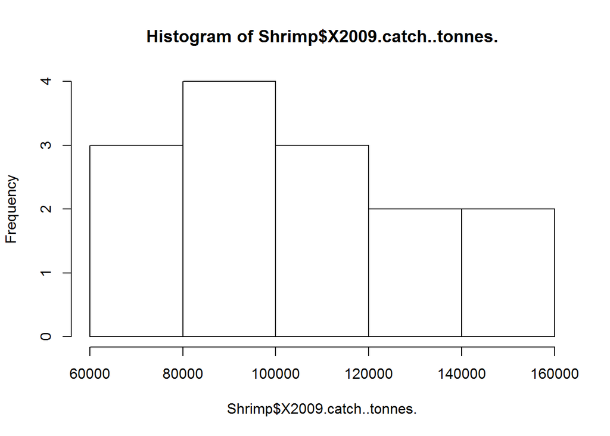

```r
hist(Shrimp$X2009.catch..tonnes.)
```

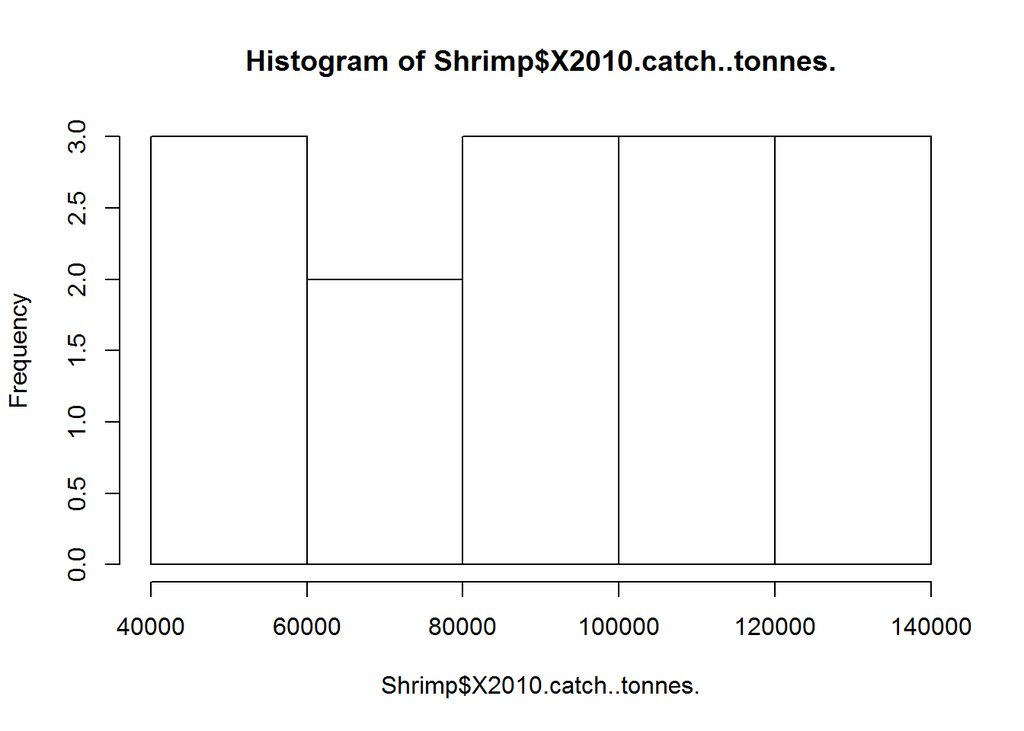

```r
hist(Shrimp$X2010.catch..tonnes.)
```

#C) #For this scenerio we would want to use a paired two-samle t-test that would compare the mean between both years of shrimp yields.

```r
#d)
post=(Shrimp$X2010.catch..tonnes.)
pre=(Shrimp$X2009.catch..tonnes.)
t.test(post, pre, paired=TRUE)
```

```
##
##  Paired t-test
##
## data:  post and pre
## t = -6.3808, df = 13, p-value = 2.415e-05
## alternative hypothesis: true difference in means is not equal to 0
## 95 percent confidence interval:
##  -17975.138  -8882.005
## sample estimates:
## mean of the differences
##               -13428.57
```

```r
qt(0.95,(14-1))
```

```
## [1] 1.770933
```

#e) # The critical value is +-1.770933, our observed value is is -6.3808 #f) # The observed value is in the critical region, additionally the pvalue<0.05, we would therfore reject the null hypothesis and there is a significant change between shrimp harvest from 2009 to 2010.

## Scenerio 2.

#a) #Null Hypotheses:The total phosphorous level is 15ug/L or less #ALternate Hypotheses: The amount of phosphorous is more than 15ug/L

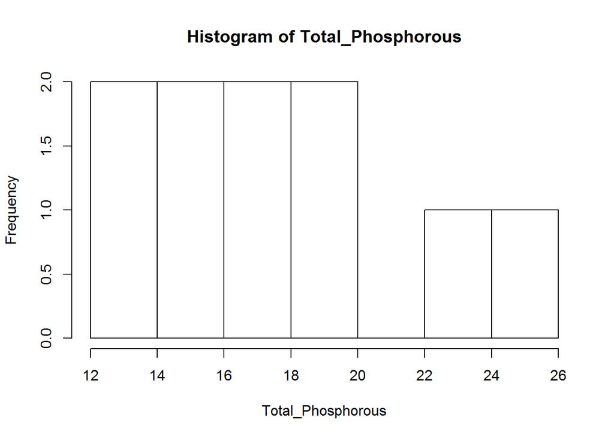

```r
#b)
Total_Phosphorous=c(18.4, 12.9, 15.3, 18.3, 15.6, 23.3, 16.5, 12.3, 24.6, 16.2)
hist(Total_Phosphorous)
```

#C) #For this scenerio we would want to use a one-sample t-test that would compare the mean between the water sample of phosphorous.

```r
#d)

t.test(Total_Phosphorous, mu=15)
```

```
##
##  One Sample t-test
##
## data:  Total_Phosphorous
## t = 1.8462, df = 9, p-value = 0.09794
## alternative hypothesis: true mean is not equal to 15
## 95 percent confidence interval:
##  14.47278 20.20722
## sample estimates:
## mean of x
##     17.34
```

```r
qt(0.95,(10-1))
```

```
## [1] 1.833113
```

#e) # The critical value is +1.833113, our observed value is is 1.8462 #f) # The observed value is in the critical region, we would therfore reject the null hypothesis and the level of phosphorous is over the maximum guidline of 15ug/l.

## Scenerio 3.

#a) #Null Hypotheses:There is no diffrence in growth rate of fish. #ALternate Hypotheses: There is a diffrence in the growth rate of fish.

```r
#b)
Fish=read.csv(file.choose())
Fish
```

```
##    Trial Carnivorous Vegetarian
## 1      1         2.3        1.6
## 2      2         1.8        1.1
## 3      3         1.9        0.7
## 4      4         1.8        1.0
## 5      5         2.1        1.0
## 6      6         2.3        0.9
## 7      7         2.0        1.2
## 8      8         2.2        0.8
## 9      9         2.2        0.9
## 10    10         1.5        0.6
## 11    11         1.8        0.7
## 12    12         2.1        0.6
## 13    13         2.3        0.8
## 14    14         2.2        0.8
```

[output cut: 33 more lines]

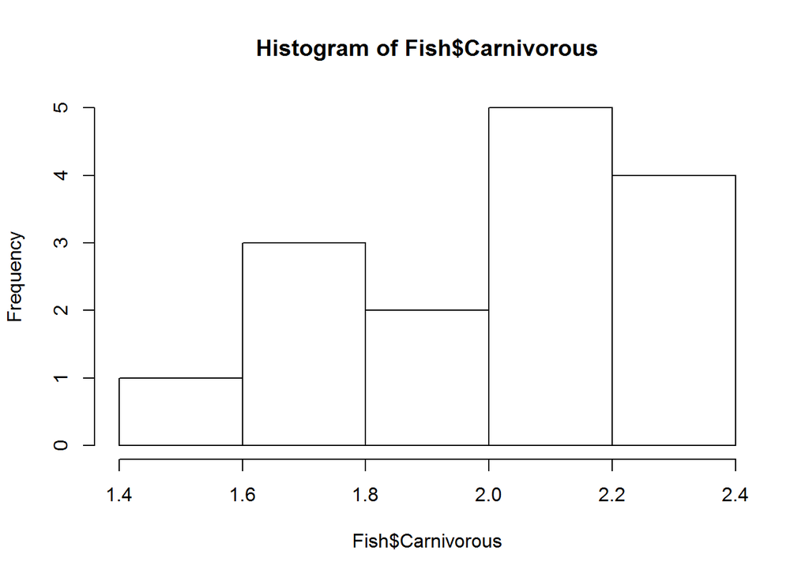

```r
hist(Fish$Carnivorous)
```

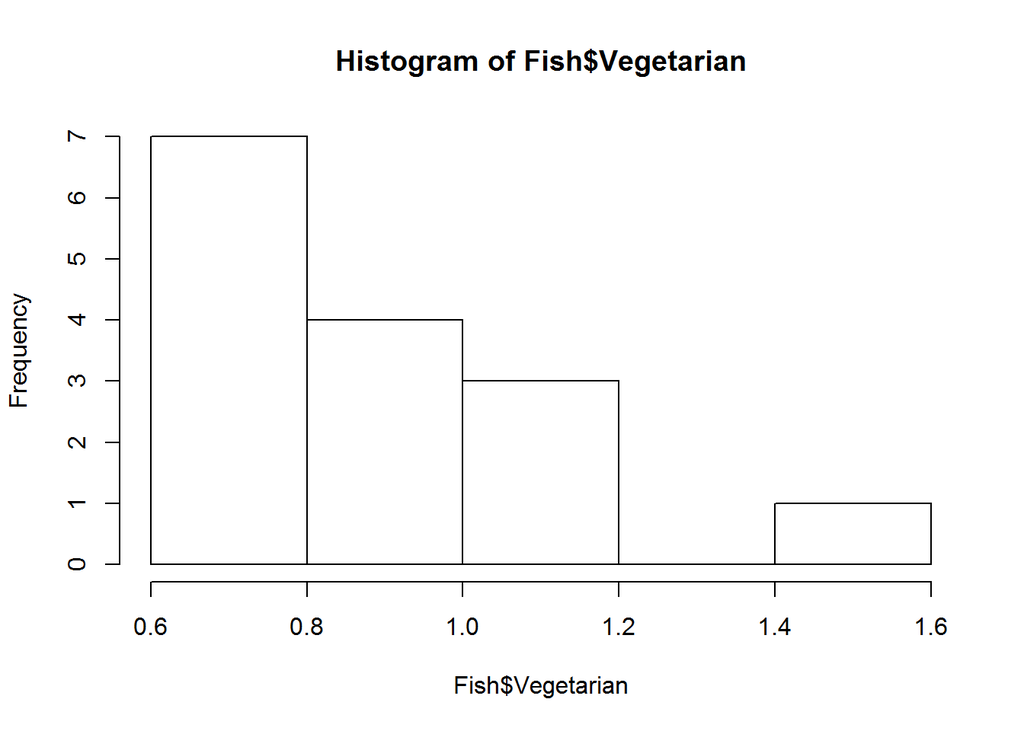

```r
hist(Fish$Vegetarian)
```

```r
#d)
post=(Fish$Carnivorous)
pre=(Fish$Vegetarian)
t.test(post, pre, paired=TRUE)
```

```
##
##  Paired t-test
##
## data:  post and pre
## t = 15.162, df = 14, p-value = 4.415e-10
## alternative hypothesis: true difference in means is not equal to 0
## 95 percent confidence interval:
##  0.9730143 1.2936524
## sample estimates:
## mean of the differences
##                1.133333
```

```r
qt(0.95,(15-1))
```

```
## [1] 1.76131
```

#e) # The critical value is +-1.76131, our observed value is is 15.162 #f) # The observed value is in the critical region, additionally the pvalue<0.05, we would therfore reject the null hypothesis and the vegeterian diet differs from the carnivorous diet in terms of growth rate.

## Scenerio 4.

#a) #Null Hypotheses: PCB poisoning is equall between trophic levels. #ALternate Hypotheses: PCB poisoning is not equall between trophic levels.

```r
#b)
#Histogram is not relevant for this part, but I did it anyways as per the question.
PCB=read.csv(file.choose())
PCB
```

```
##                   X No.effect No.reproduction Death Column.Total
## 1 1st Trophic level       133             100    17          250
## 2      Top Predator         4              61    35          100
## 3        Row Totals       137             161    52          350
```

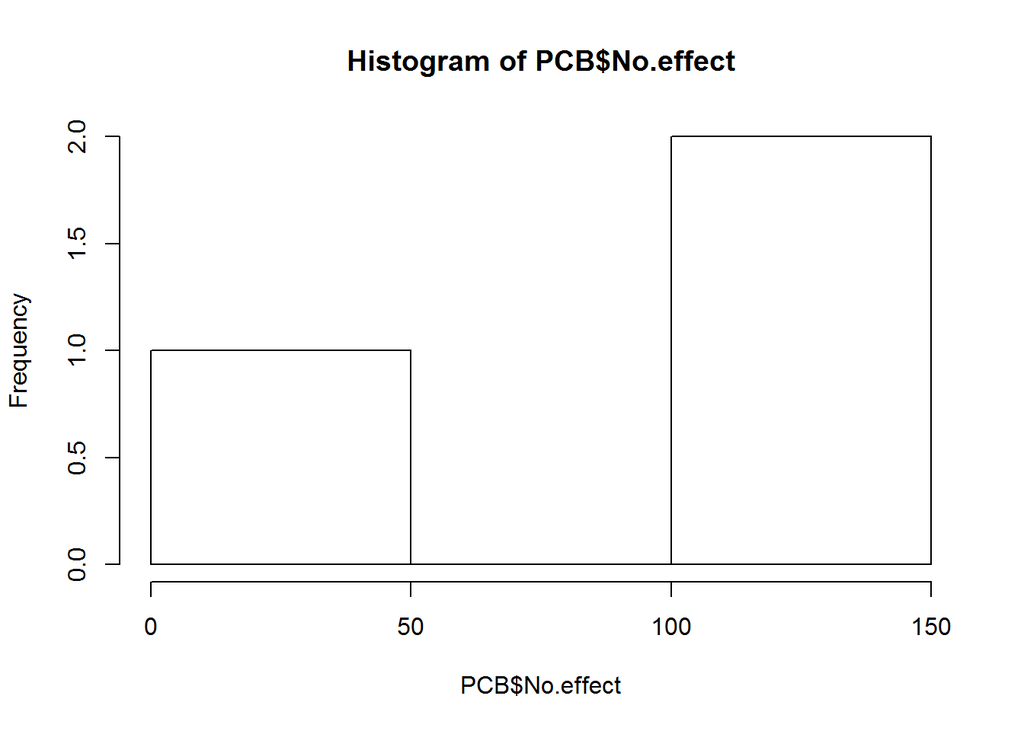

```r
hist(PCB$No.effect)
```

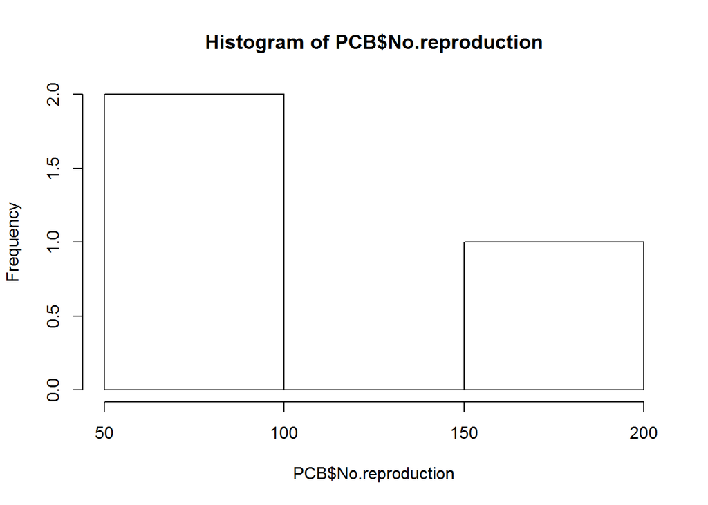

```r
hist(PCB$No.reproduction)
```

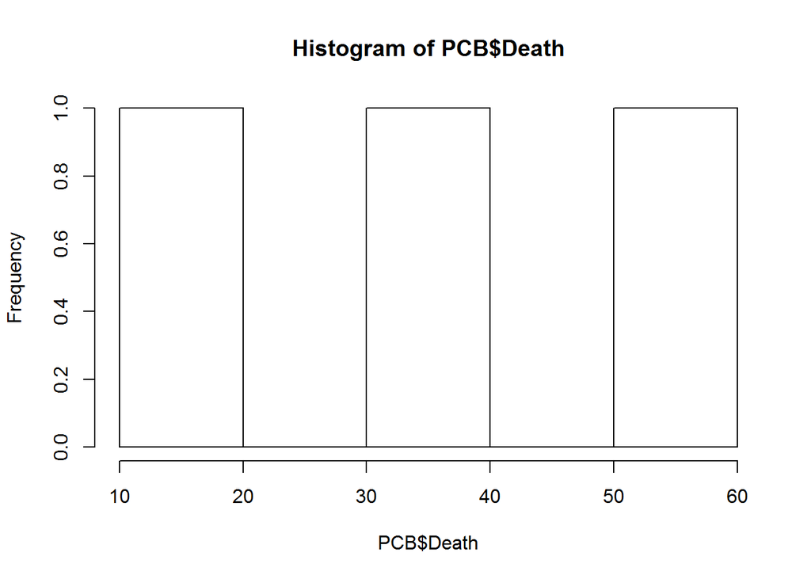

```r
hist(PCB$Death)
```

#C) #For this scenerio we would want to use a chi-squared that would compare independance between categorical variables.

```r
#d)
FirstTrophicLevel=c(133,    100,    17)
TopPredator=c(4, 61, 35)
pcb=data.frame('F'=FirstTrophicLevel, 'T'=TopPredator)

chisq.test(pcb)
```

```
##
##  Pearson's Chi-squared test
##
## data:  pcb
## X-squared = 89.253, df = 2, p-value < 2.2e-16
```

```r
qchisq(0.95,2)
```

```
## [1] 5.991465
```

#e) # The critical value is +-5.991465, our observed value is is 89.253 #f) # The observed value is in the critical region, additionally the pvalue<0.05, we would therfore reject the null hypothesis and the pcb levels are unequal between the 1st trophic level and top predators.